# Part II - Types of users and the times that they ride

## by Timothy Lee Quan

## Investigation Overview

In this investigation, our intent is to examine the time and day of rides and how it relates to the user type:

- Distribution of ride start times - what are the peak times that people start rides?
- User type by rides - in what proportion are the user types represented (customer vs subscriber)?
- Average ride duration by user type - does one user type ride longer than the other?
- Duration by day of week and hour of day: customer vs subscriber - Given any differences in duration for customers and subscribers, do they share any trends or distinctions by week and time of day?
- Top riding times by day of week and hour of day: customer vs subscriber - Given any trends in peak times to start rides, are they shared or distinct with the user types?

## Dataset Overview

The dataset contains 183,413 records of bike rides as part of the "Ford GoBike" sharing program in February 2019 only. Each row represents a 'ride', and contain a combination of time, location, and user data for each ride.

## Distribution of ride start times

> Peak usage time is between 07:00-10:00 and then again between 16:00-20:00 on weekdays. This may indicate a primary use case being commuting.

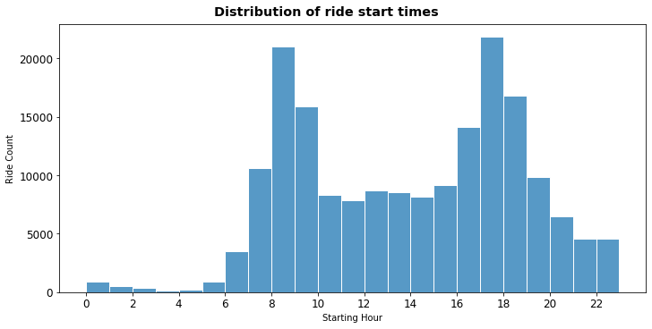

## Distribution of user type by rides

> There are two user types; customer and subscriber. Subscribers make up the lions share of overall ride count, meaning they account for the majority of ride records. The dataset doesn't identify unique subscribers (or customers for that matter); so, there's no way to compare how many subscribers and customers there are.

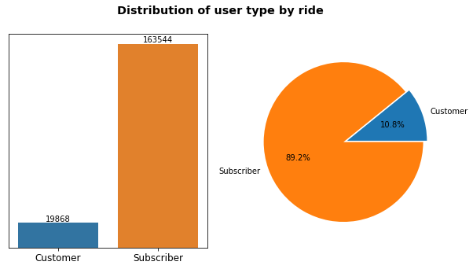

## Average ride duration by user type

Comparing the ride durations shows that on average, customers rides are twice as long as subscribers. This infer something about the nature of subscribers vs. customers; Are customers more likely to ride for leisure? Or, if using this bike share program is outside of their usual routine, maybe it takes them twice as long to find their way from A to B?

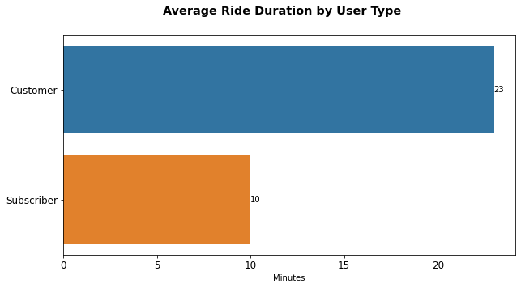

## Duration by day of week vs hour of day: Customer vs Subscriber

As one might predict, rides tend to be a bit longer on Saturdays and Sundays. It is however a surprise to see that late at night and the wee hours of the morning we see longer rides too, which might indicate something about nightlife. Customer and subscribers share in this trend, with customers still having longer rides on average.

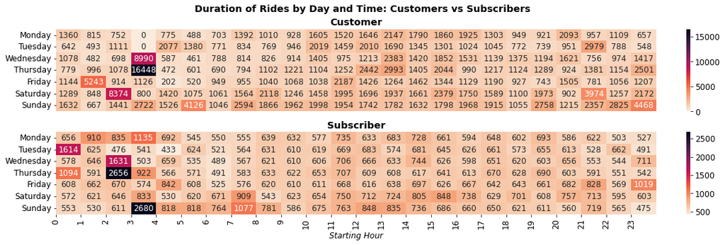

## Top riding times by day of week and hour of day: Customer vs Subscriber

On weekdays, customers and subscribers don't seem to differ much in terms of the times they ride. On weekends though, the peak ride times almost reverse with more riders in the middle of the day. This trend is more apparent with customers (non-subscribers)

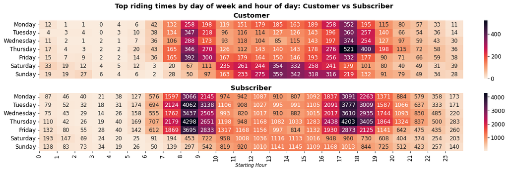